# Cx4073 : Assignment 1

Fong Hou Jun

13 Feb 2020

### Analysis of Naval Propulsion Data

Import the CSV data file `assign1_NavalData.csv` for analysis, and quickly check the structure of the data.

```r
navalData <- read.csv("assign1_NavalData.csv", header = TRUE)
str(navalData)
```

```
## 'data.frame':    10000 obs. of  18 variables:
##  $ X1 : num  3.14 7.15 5.14 4.16 9.3 9.3 2.09 1.14 8.21 8.21 ...
##  $ X2 : int  9 21 15 12 27 27 6 3 24 24 ...
##  $ X3 : num  8374 39007 21639 14722 72759 ...
##  $ X4 : num  1387 2678 1924 1547 3560 ...
##  $ X5 : num  7014 9116 8514 7758 9729 ...
##  $ X6 : num  60.3 332.5 175.3 113.8 644.7 ...
##  $ X7 : num  60.3 332.5 175.3 113.8 644.7 ...
##  $ X8 : num  586 822 705 653 1058 ...
##  $ X9 : int  288 288 288 288 288 288 288 288 288 288 ...
##  $ X10: num  578 687 640 610 772 ...
##  $ X11: num  1.39 2.99 2.07 1.66 4.55 4.52 1.33 1.26 3.6 3.58 ...
##  $ X12: int  1 1 1 1 1 1 1 1 1 1 ...
##  $ X13: num  7.6 15.71 10.92 9.01 22.96 ...
##  $ X14: num  1.02 1.04 1.03 1.02 1.05 1.05 1.02 1.02 1.04 1.04 ...
##  $ X15: num  12.3 44 24.9 17.8 88.3 ...
##  $ X16: num  0.24 0.87 0.49 0.35 1.75 1.79 0.26 0.25 1.18 1.22 ...
##  $ Y1 : num  0.99 0.99 0.95 0.97 1 0.97 0.99 0.99 1 0.96 ...
##  $ Y2 : num  0.98 0.98 1 0.98 0.98 0.98 1 0.99 0.99 0.98 ...
```

Importing all necessary libraries for the assignment.

```r
library(dplyr)
```

```r
library(corrplot)
library(RColorBrewer)
```

The following table summarizes the features/variables in the dataset. You will also find them in the text file `assign1_FeatureNames.txt`. The features/variables `X1` to `X16` are the predictors, while `Y1` and `Y2` are the *target* response variables.

| Variable | Description |
| --- | --- |
| X1 | Lever position (lp) |
| X2 | Ship speed (v) [knots] |
| X3 | Gas Turbine shaft torque (GTT) [kN m] |
| X4 | Gas Turbine rate of revolutions (GTn) [rpm] |
| X5 | Gas Generator rate of revolutions (GGn) [rpm] |
| X6 | Starboard Propeller Torque (Ts) [kN] |
| X7 | Port Propeller Torque (Tp) [kN] |
| X8 | HP Turbine exit temperature (T48) [C] |
| X9 | GT Compressor inlet air temperature (T1) [C] |
| X10 | GT Compressor outlet air temperature (T2) [C] |
| X11 | HP Turbine exit pressure (P48) [bar] |
| X12 | GT Compressor inlet air pressure (P1) [bar] |
| X13 | GT Compressor outlet air pressure (P2) [bar] |
| X14 | Gas Turbine exhaust gas pressure (Pexh) [bar] |
| X15 | Turbine Injecton Control (TIC) [%] |
| X16 | Fuel flow (mf) [kg/s] |
| Y1 | GT Compressor decay state coefficient |
| Y2 | GT Turbine decay state coefficient |

The data is from a simulator of a naval vessel, characterized by a Gas Turbine (GT) propulsion plant. You may treat the available data as if it is from a hypothetical naval vessel. The propulsion system behaviour has been described with the parameters `X1` to `X16`, as detailed above, and the target is to predict the performance decay of the GT components such as *GT Compressor* and *GT Turbine*.

**Task** : Build the best possible Linear Model you can to predict both `Y1` and `Y2`, using the training dataset `assign1_NavalData.csv`. Then predict `Y1` and `Y2` values using your model on the test dataset `assign1_NavalPred.csv`.

**Continue with Exploratory Data Analysis, Model Building and Prediction. Submit this .Rmd file as your Solution : [StudentID].Rmd**

### Basic Exploration of CSV file

Dimensions of the loaded dataset

```r
dim(navalData)
```

```
## [1] 10000    18
```

Labels of the columns in csv file.

```r
names(navalData)
```

```
##  [1] "X1"  "X2"  "X3"  "X4"  "X5"  "X6"  "X7"  "X8"  "X9"  "X10" "X11" "X12"
## [13] "X13" "X14" "X15" "X16" "Y1"  "Y2"
```

Names function gives us all the names of the variables in the dataset.

Structure of the loaded dataset

```r
str(navalData)
```

```
## 'data.frame':    10000 obs. of  18 variables:
##  $ X1 : num  3.14 7.15 5.14 4.16 9.3 9.3 2.09 1.14 8.21 8.21 ...
##  $ X2 : int  9 21 15 12 27 27 6 3 24 24 ...
##  $ X3 : num  8374 39007 21639 14722 72759 ...
##  $ X4 : num  1387 2678 1924 1547 3560 ...
##  $ X5 : num  7014 9116 8514 7758 9729 ...
##  $ X6 : num  60.3 332.5 175.3 113.8 644.7 ...
##  $ X7 : num  60.3 332.5 175.3 113.8 644.7 ...
##  $ X8 : num  586 822 705 653 1058 ...
##  $ X9 : int  288 288 288 288 288 288 288 288 288 288 ...
##  $ X10: num  578 687 640 610 772 ...
##  $ X11: num  1.39 2.99 2.07 1.66 4.55 4.52 1.33 1.26 3.6 3.58 ...
##  $ X12: int  1 1 1 1 1 1 1 1 1 1 ...
##  $ X13: num  7.6 15.71 10.92 9.01 22.96 ...
##  $ X14: num  1.02 1.04 1.03 1.02 1.05 1.05 1.02 1.02 1.04 1.04 ...
##  $ X15: num  12.3 44 24.9 17.8 88.3 ...
##  $ X16: num  0.24 0.87 0.49 0.35 1.75 1.79 0.26 0.25 1.18 1.22 ...
##  $ Y1 : num  0.99 0.99 0.95 0.97 1 0.97 0.99 0.99 1 0.96 ...
##  $ Y2 : num  0.98 0.98 1 0.98 0.98 0.98 1 0.99 0.99 0.98 ...
```

Structure shows us what kind of data is loaded. `X2`, `X9` and `X12` show are of integer data types, while the rest are numeric data types.

First few rows of the loaded dataset

```r
head(navalData)
```

```
##     X1 X2       X3      X4      X5     X6     X7      X8  X9    X10  X11 X12
## 1 3.14  9  8373.85 1386.72 7013.62  60.28  60.28  585.98 288 578.07 1.39   1
## 2 7.15 21 39007.12 2678.01 9116.04 332.49 332.49  821.74 288 686.53 2.99   1
## 3 5.14 15 21639.19 1924.36 8513.72 175.32 175.32  705.11 288 640.12 2.07   1
## 4 4.16 12 14721.84 1547.46 7757.85 113.78 113.78  653.07 288 610.15 1.66   1
## 5 9.30 27 72759.21 3560.37 9729.10 644.74 644.74 1057.88 288 771.58 4.55   1
## 6 9.30 27 72763.86 3560.39 9755.85 644.76 644.76 1086.81 288 780.50 4.52   1
##     X13  X14   X15  X16   Y1   Y2
## 1  7.60 1.02 12.35 0.24 0.99 0.98
## 2 15.71 1.04 43.97 0.87 0.99 0.98
## 3 10.92 1.03 24.89 0.49 0.95 1.00
## 4  9.01 1.02 17.77 0.35 0.97 0.98
## 5 22.96 1.05 88.27 1.75 1.00 0.98
## 6 22.85 1.05 90.41 1.79 0.97 0.98
```

Last few rows of the loaded dataset

```r
tail(navalData)
```

```
##         X1 X2       X3      X4      X5     X6     X7      X8  X9    X10  X11
## 9995  7.15 21 39003.56 2678.03 9117.88 332.36 332.36  826.01 288 688.20 2.98
## 9996  8.21 24 50980.73 3087.03 9292.11 437.85 437.85  922.31 288 727.73 3.61
## 9997  9.30 27 72769.02 3560.39 9751.42 644.80 644.80 1068.72 288 775.77 4.52
## 9998  9.30 27 72771.02 3560.40 9747.98 644.90 644.90 1056.83 288 772.58 4.53
## 9999  5.14 15 21624.59 1924.34 8468.24 175.25 175.25  683.49 288 629.30 2.09
## 10000 2.09  6  4500.88 1392.71 6842.73  31.20  31.20  534.26 288 564.56 1.26
##       X12   X13  X14   X15  X16   Y1   Y2
## 9995    1 15.71 1.04 44.23 0.88 0.99 0.98
## 9996    1 18.79 1.04 60.69 1.20 1.00 0.98
## 9997    1 22.69 1.05 88.78 1.76 0.98 0.99
## 9998    1 22.61 1.05 87.72 1.74 0.99 0.99
## 9999    1 11.01 1.03 23.91 0.47 1.00 1.00
## 10000   1  6.73 1.02  0.00 0.17 0.97 1.00
```

**Basic Visualizations : Histograms**

X1 : Lever position (lp)

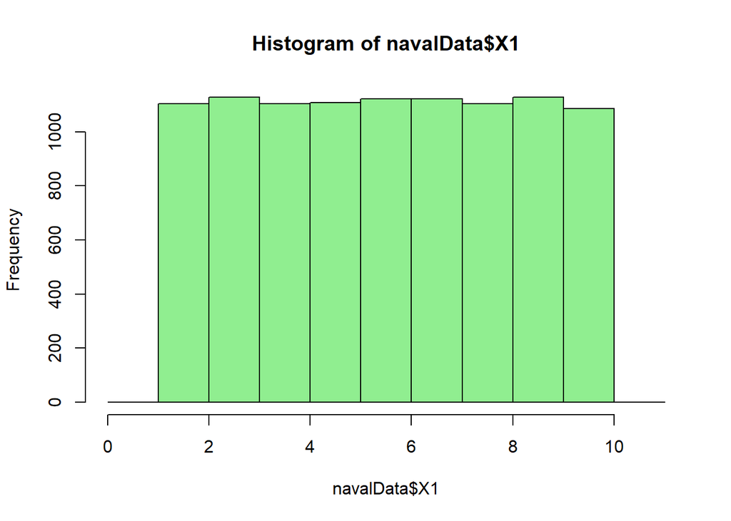

```r
hist(navalData$X1, breaks = seq(0, 11, by = 1), col = "lightgreen")
```

X2 : Ship speed (v) [knots]

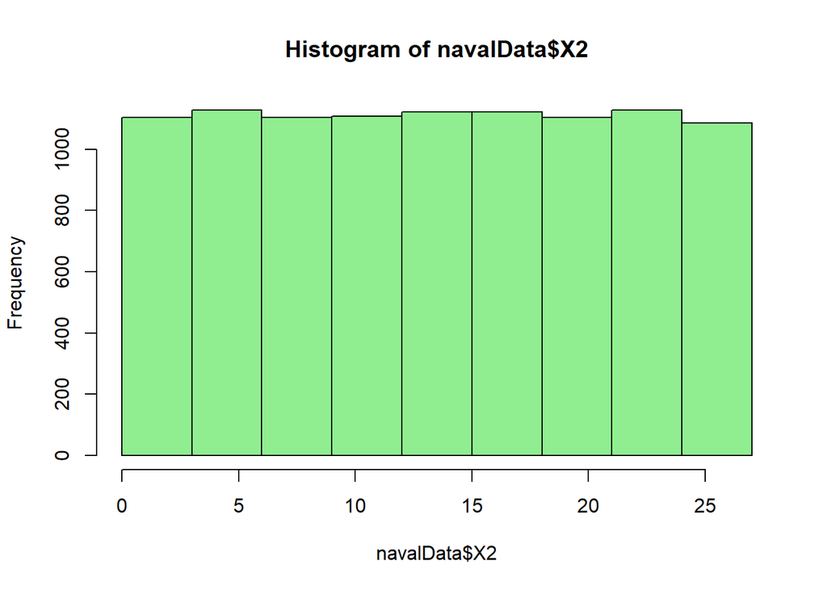

```r
hist(navalData$X2, breaks = seq(0, 27, by = 3), col = "lightgreen")
```

X3 : Gas Turbine shaft torque (GTT) [kN m]

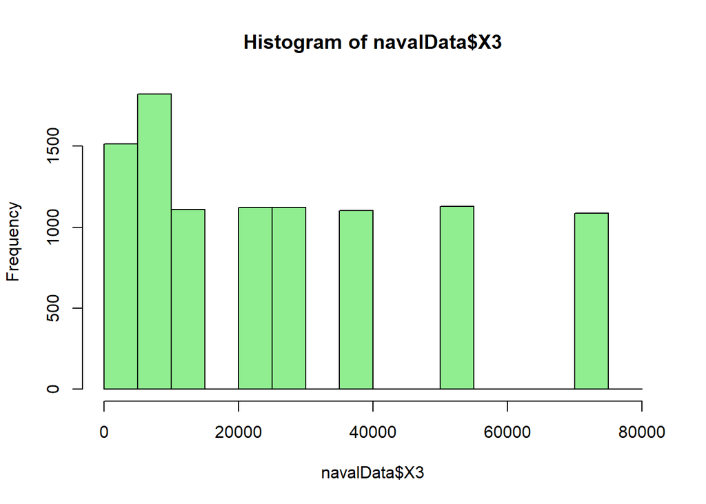

```r
hist(navalData$X3, breaks = seq(0, 80000, by = 5000), col = "lightgreen")
```

X4 : Gas Turbine rate of revolutions (GTn) [rpm]

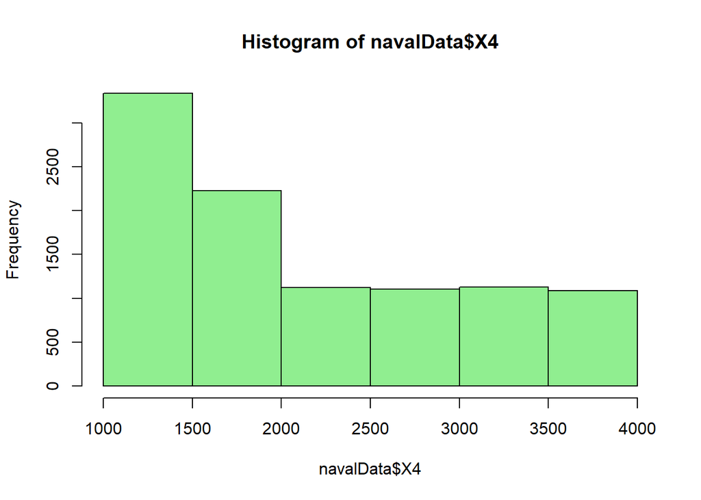

```r
hist(navalData$X4, breaks = seq(1000, 4000, by = 500), col = "lightgreen")
```

X5 : Gas Generator rate of revolutions (GGn) [rpm]

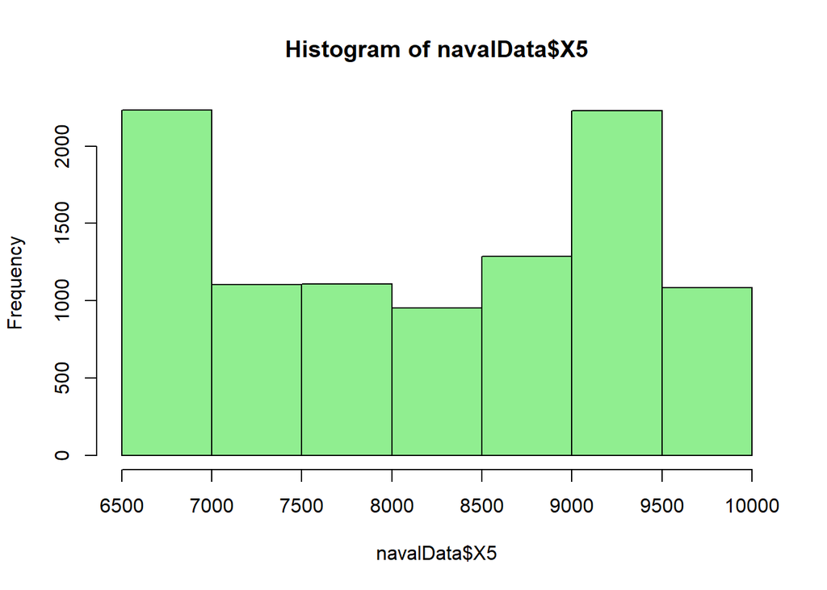

```r
hist(navalData$X5, breaks = seq(6500, 10000, by = 500), col = "lightgreen")
```

X6 : Starboard Propeller Torque (Ts) [kN]

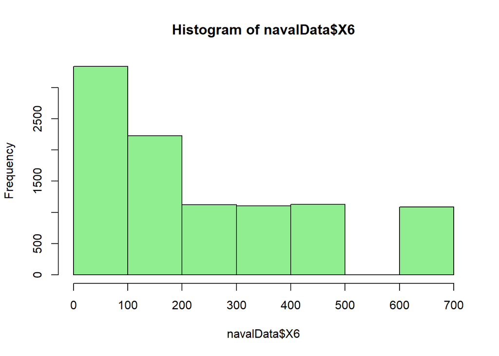

```r
hist(navalData$X6, breaks = seq(0, 700, by = 100), col = "lightgreen")
```

X7 : Port Propeller Torque (Tp) [kN]

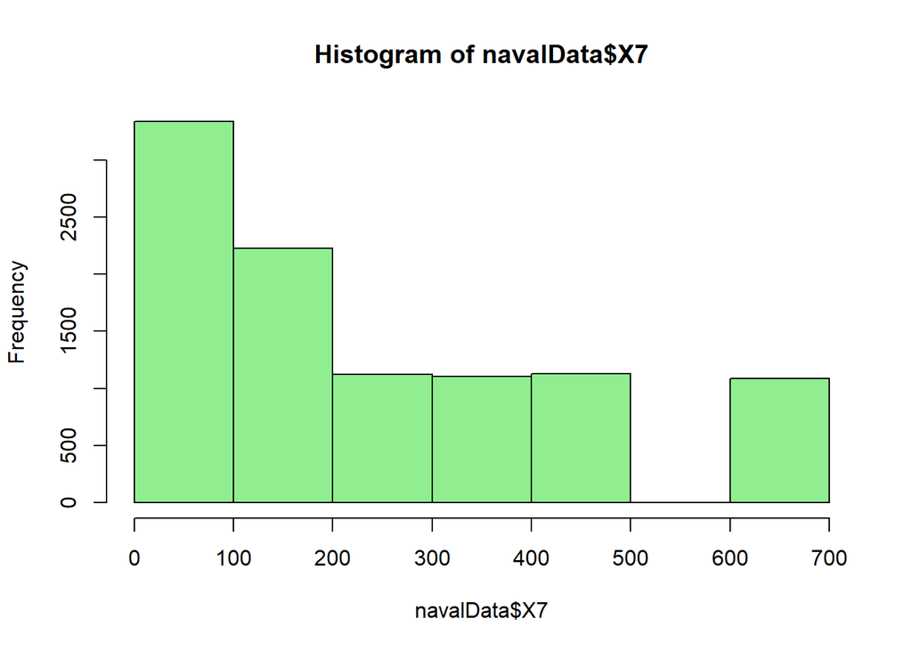

```r
hist(navalData$X7, breaks = seq(0, 700, by = 100), col = "lightgreen")
```

X8 : HP Turbine exit temperature (T48) [C]

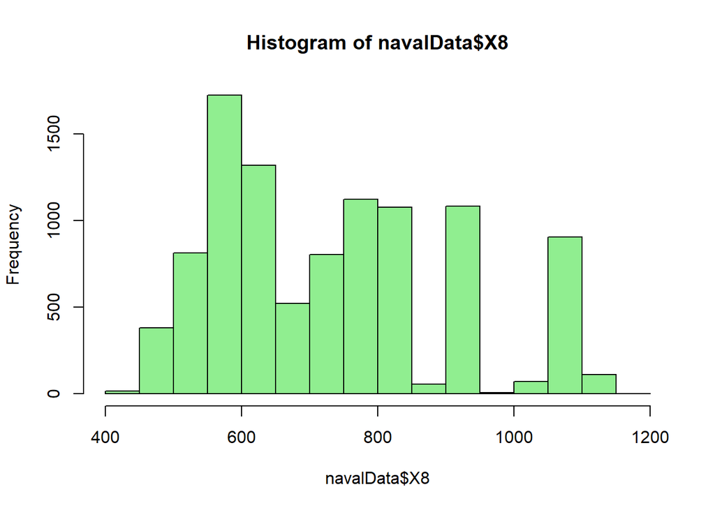

```r
hist(navalData$X8, breaks = seq(400, 1200, by = 50), col = "lightgreen")
```

X9 : GT Compressor inlet air temperature (T1) [C]

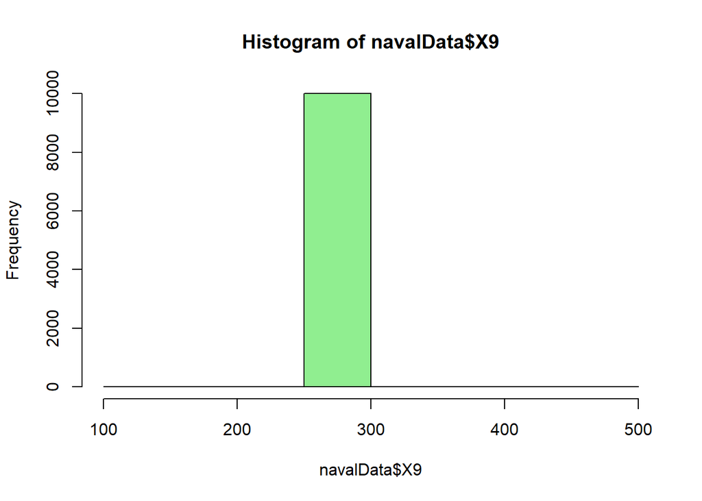

```r
hist(navalData$X9, breaks = seq(100, 500, by = 50), col = "lightgreen")
```

X10 : GT Compressor outlet air temperature (T2) [C]

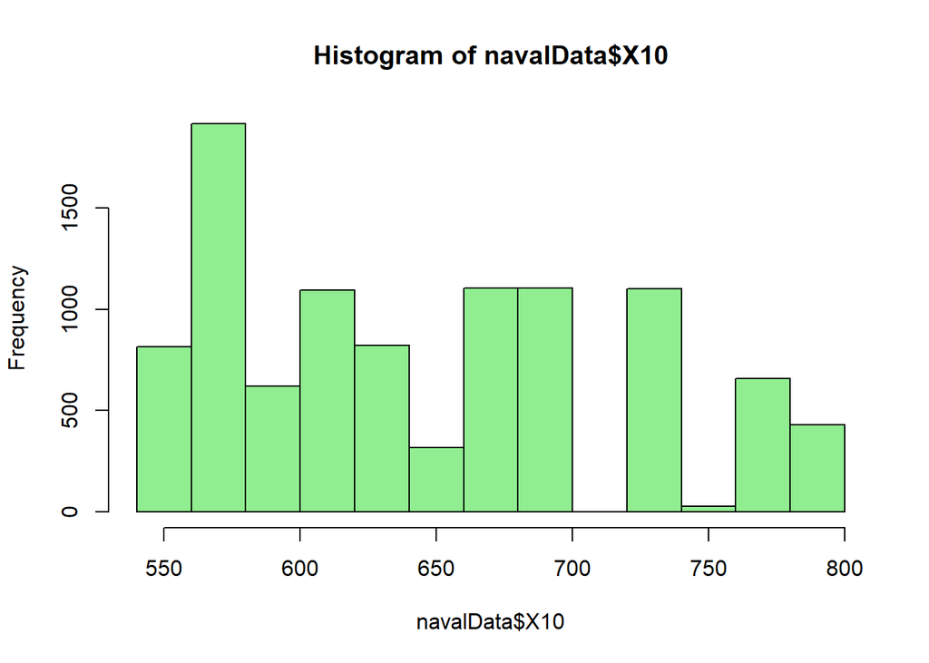

```r
hist(navalData$X10, col = "lightgreen")
```

X11 : HP Turbine exit pressure (P48) [bar]

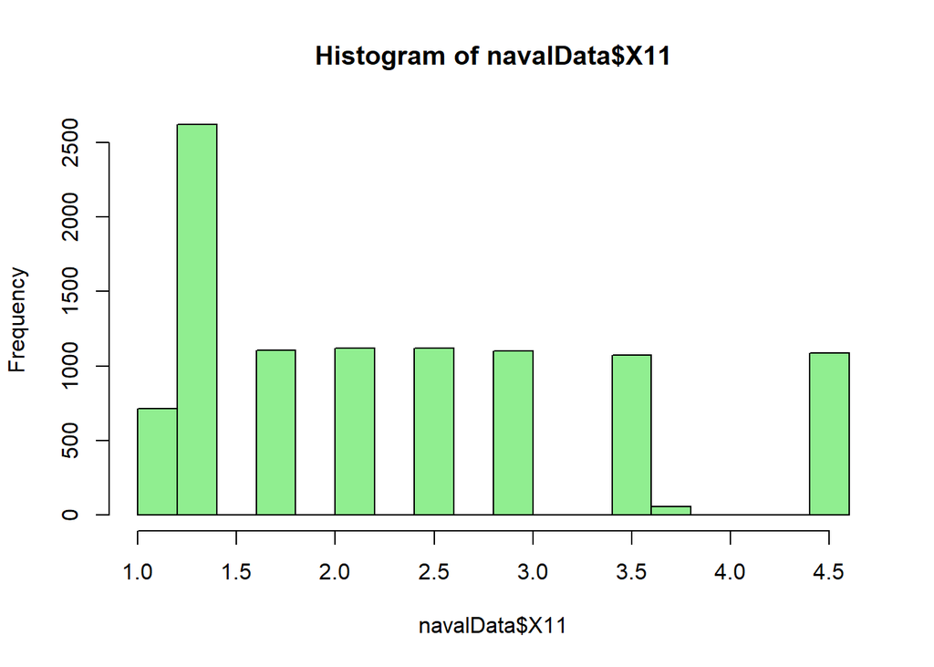

```r
hist(navalData$X11, col = "lightgreen")
```

X12 : GT Compressor inlet air pressure (P1) [bar]

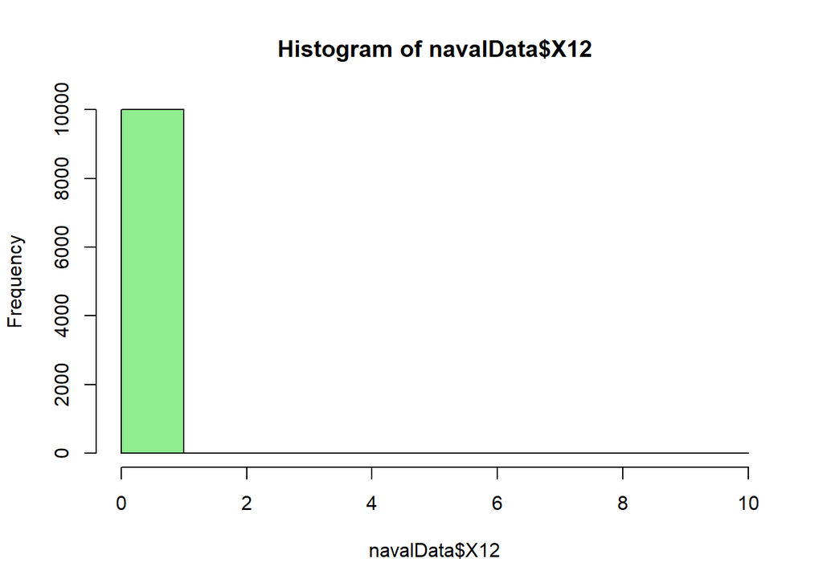

```r
hist(navalData$X12, breaks = seq(0, 10, by = 1), col = "lightgreen")
```

X13 : GT Compressor outlet air pressure (P2) [bar]

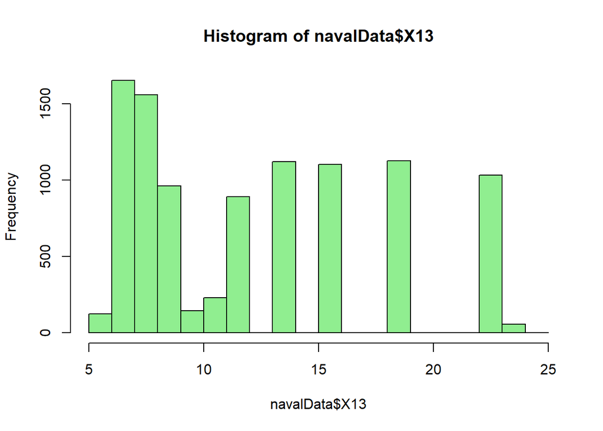

```r
hist(navalData$X13,breaks = seq(5, 25, by = 1), col = "lightgreen")
```

X14 : Gas Turbine exhaust gas pressure (Pexh) [bar]

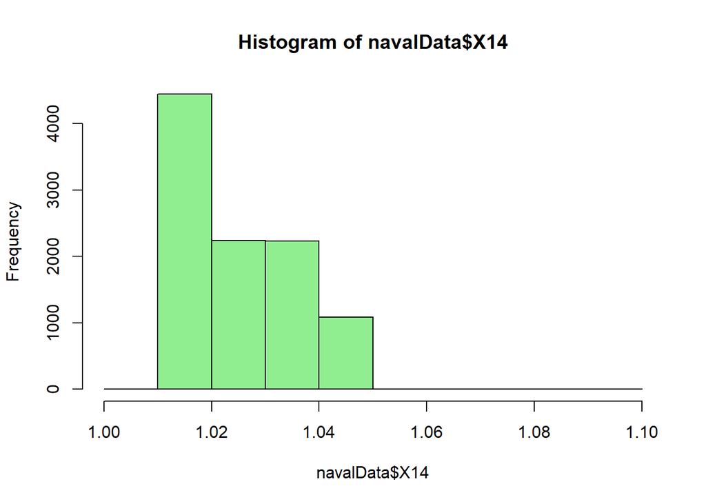

```r
hist(navalData$X14,breaks = seq(1, 1.1, by = 0.01), col = "lightgreen")
```

X15 : Turbine Injecton Control (TIC) [%]

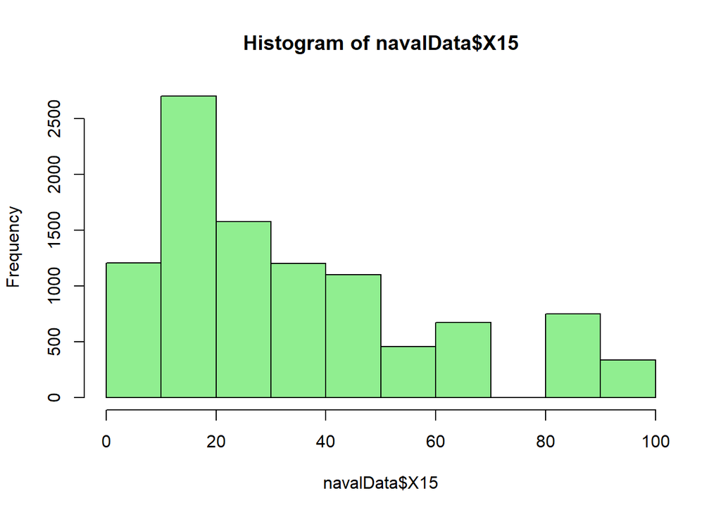

```r
hist(navalData$X15,breaks = seq(0, 100, by = 10), col = "lightgreen")
```

X16 : Fuel flow (mf) [kg/s]

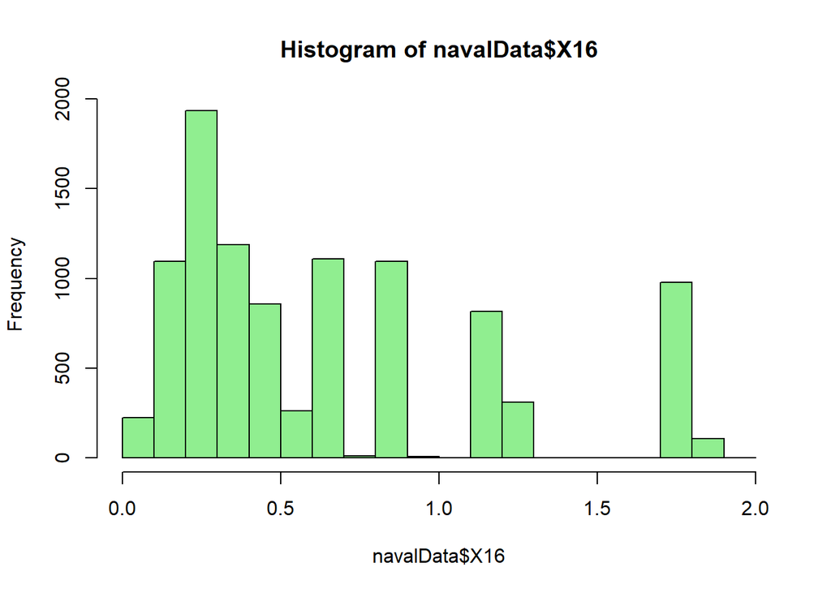

```r
hist(navalData$X16, breaks = seq(0, 2, by = 0.1), col = "lightgreen")
```

Y1 : GT Compressor decay state coefficient

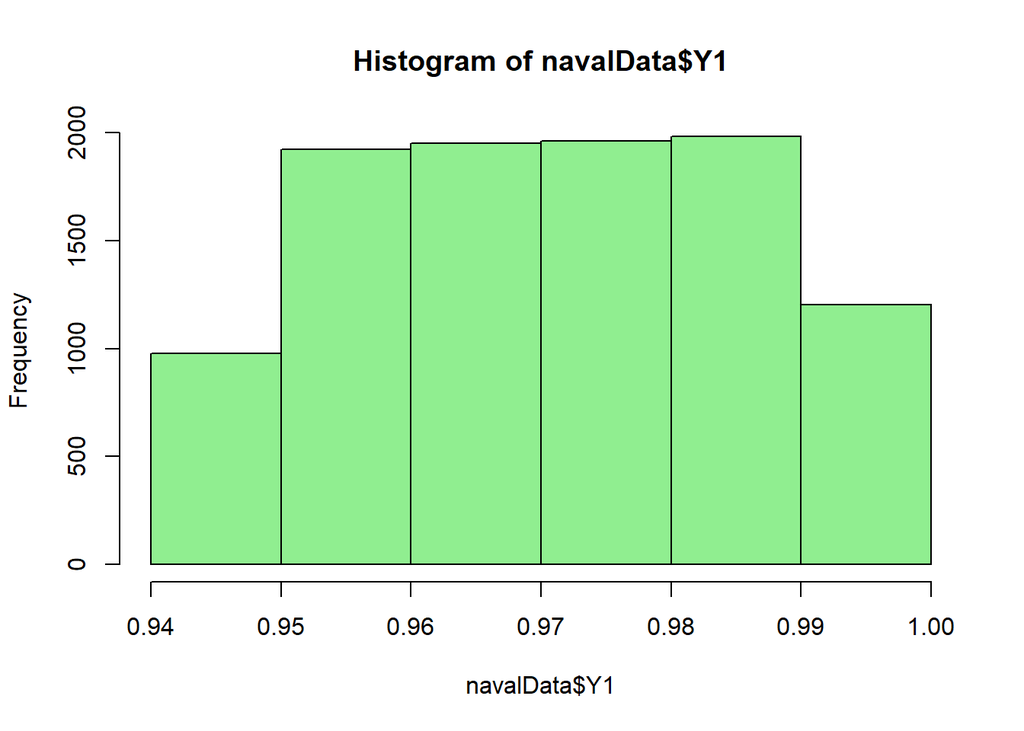

```r
hist(navalData$Y1, breaks = seq(0.94, 1, by = 0.01), col = "lightgreen")
```

Y2 : GT Turbine decay state coefficient

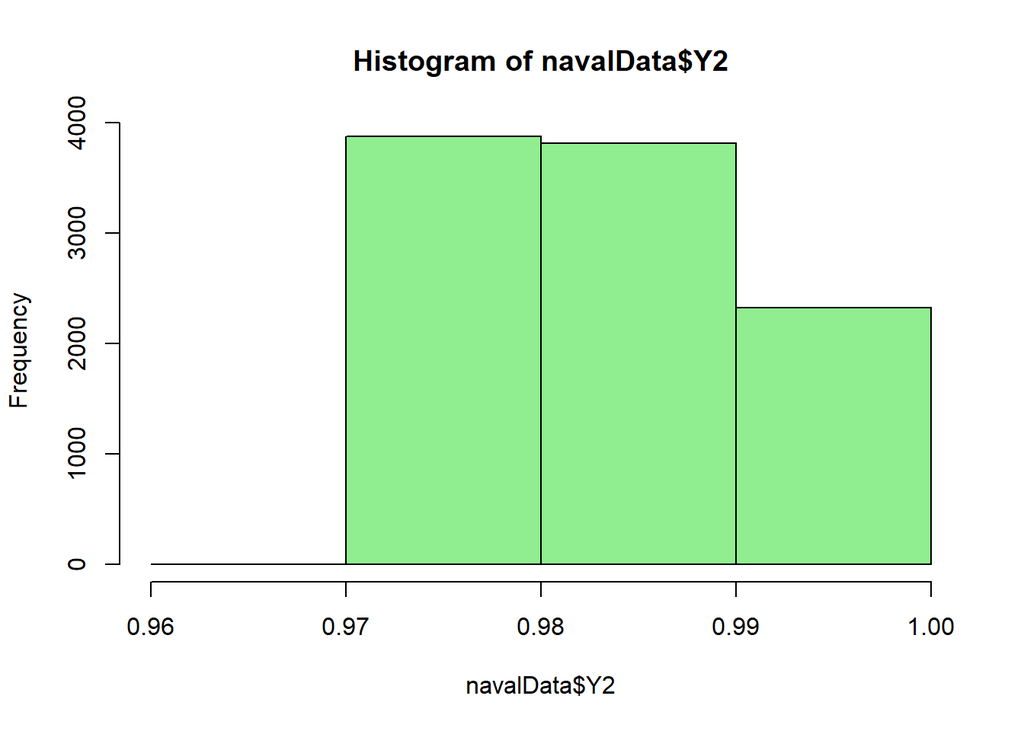

```r
hist(navalData$Y2, breaks = seq(0.96, 1, by = 0.01), col = "lightgreen")
```

**Basic Visualizations : Boxplots**

X1 : Lever position (lp)

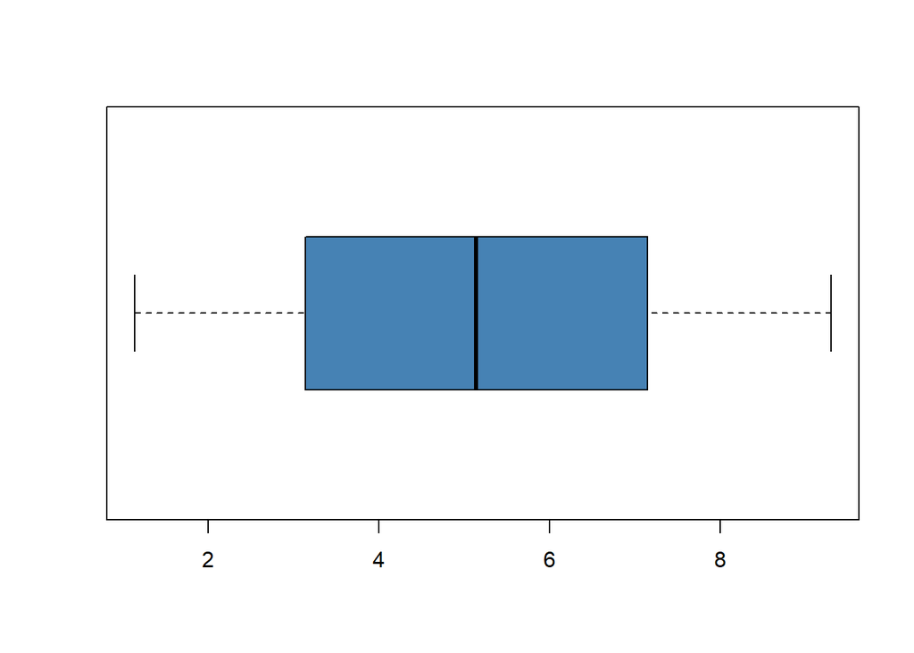

```r
boxplot(navalData$X1, horizontal = TRUE, col = "steelblue")
```

X2 : Ship speed (v) [knots]

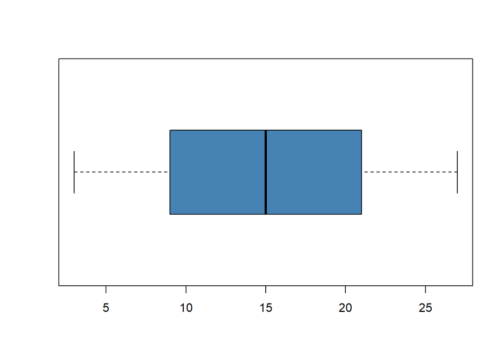

```r
boxplot(navalData$X2, horizontal = TRUE, col = "steelblue")
```

X3 : Gas Turbine shaft torque (GTT) [kN m]

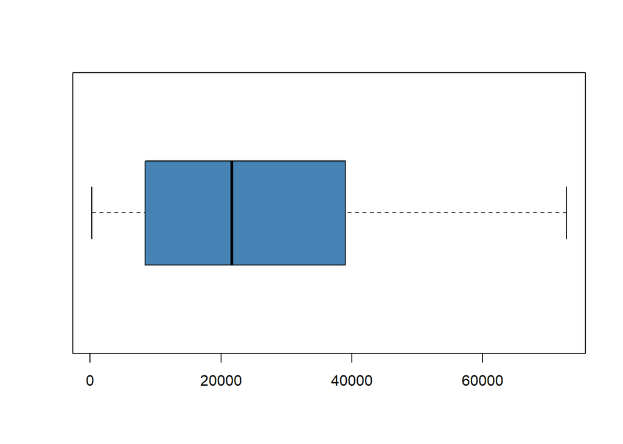

```r
boxplot(navalData$X3, horizontal = TRUE, col = "steelblue")
```

X4 : Gas Turbine rate of revolutions (GTn) [rpm]

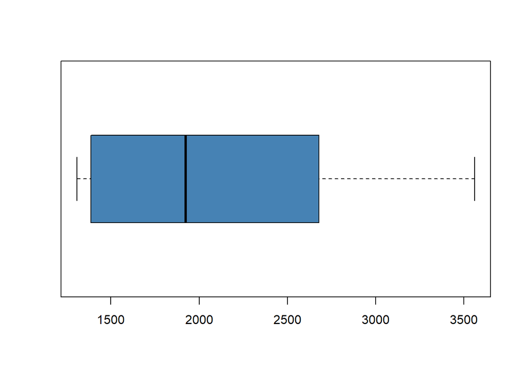

```r
boxplot(navalData$X4, horizontal = TRUE, col = "steelblue")
```

X5 : Gas Generator rate of revolutions (GGn) [rpm]

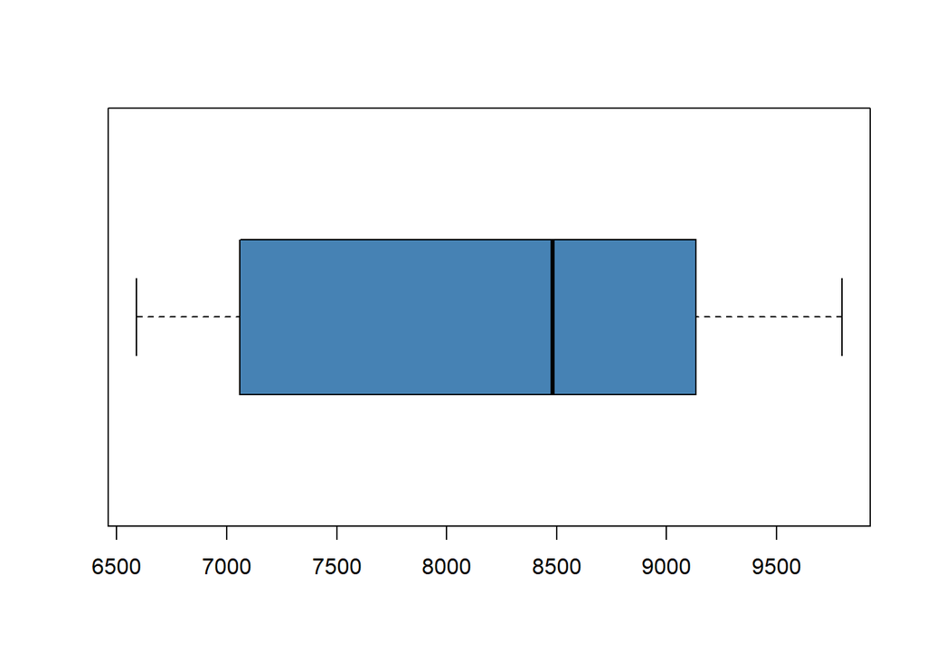

```r
boxplot(navalData$X5, horizontal = TRUE, col = "steelblue")
```

X6 : Starboard Propeller Torque (Ts) [kN]

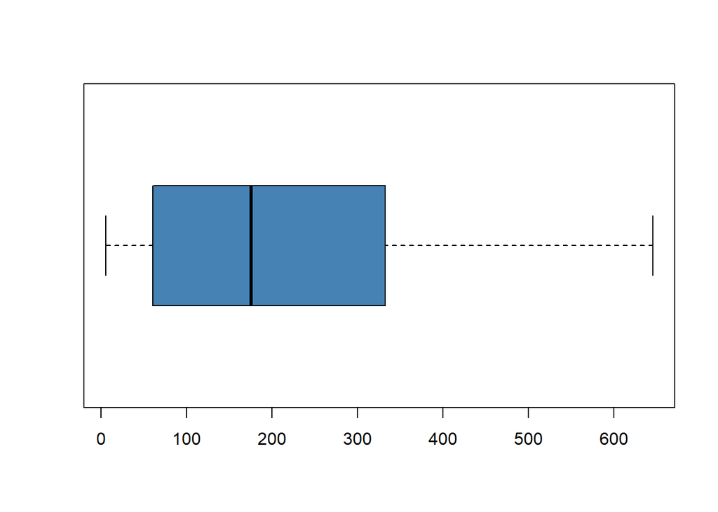

```r
boxplot(navalData$X6, horizontal = TRUE, col = "steelblue")
```

X7 : Port Propeller Torque (Tp) [kN]

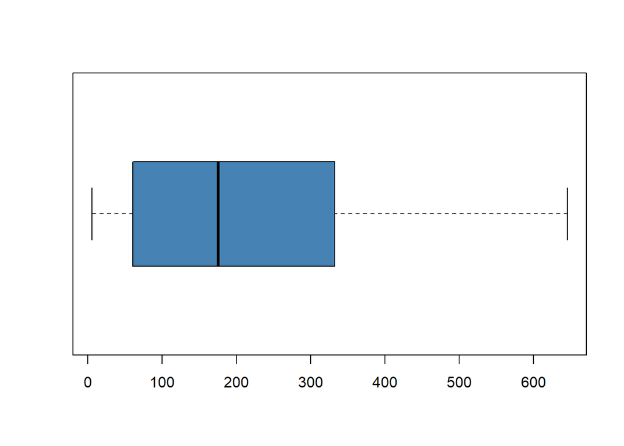

```r
boxplot(navalData$X7, horizontal = TRUE, col = "steelblue")
```

X8 : HP Turbine exit temperature (T48) [C]

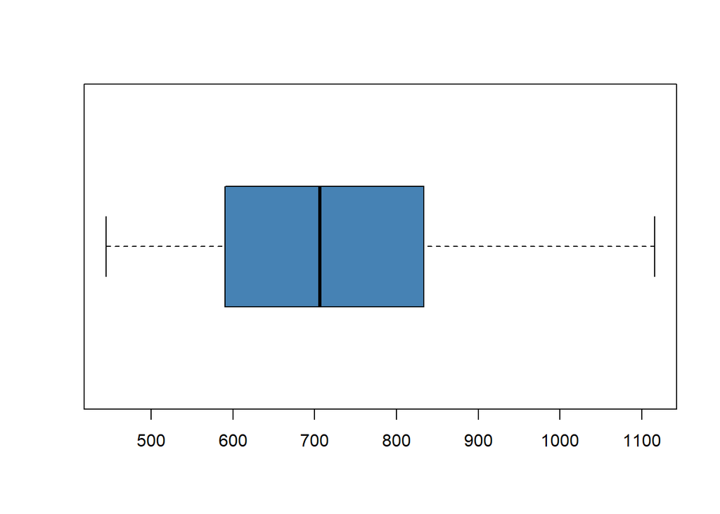

```r
boxplot(navalData$X8, horizontal = TRUE, col = "steelblue")
```

X9 : GT Compressor inlet air temperature (T1) [C]

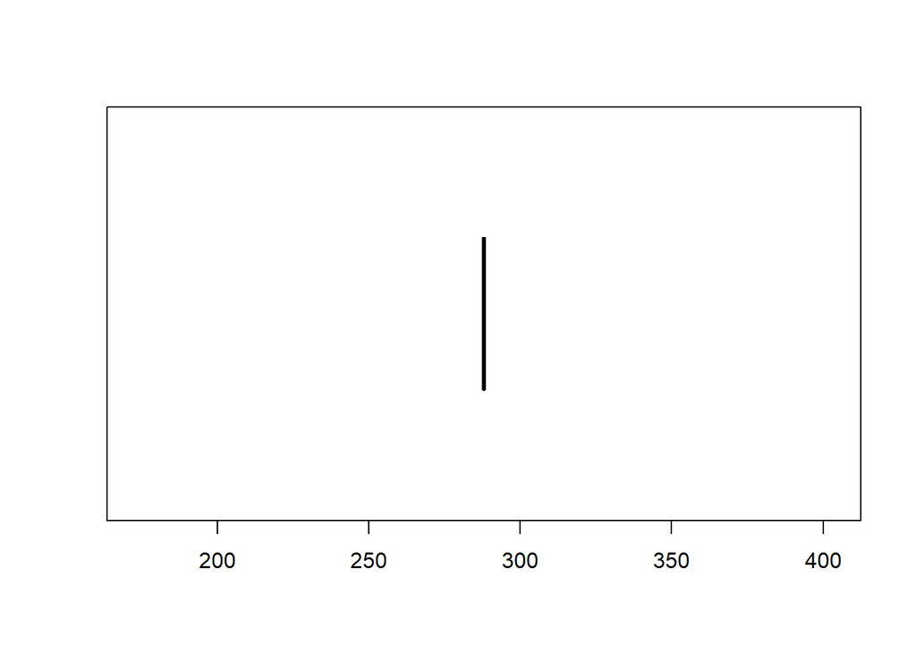

```r
boxplot(navalData$X9, horizontal = TRUE, col = "steelblue")
```

X10 : GT Compressor outlet air temperature (T2) [C]

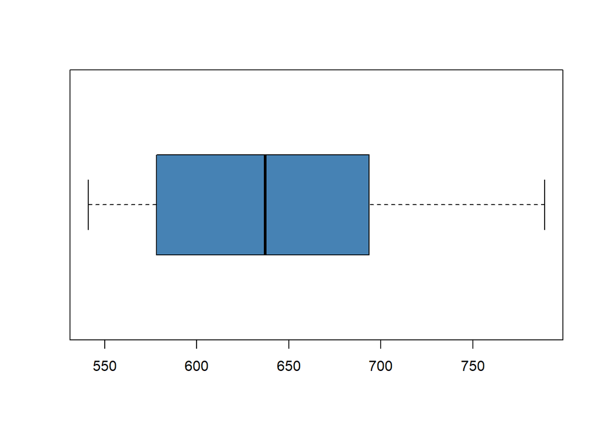

```r
boxplot(navalData$X10, horizontal = TRUE, col = "steelblue")
```

X11 : HP Turbine exit pressure (P48) [bar]